# CC3200 Host Driver Release notes

## Introduction

The SimpleLink™ Wi-Fi® CC3200/3100 device family is a single-chip with built-in Wi-Fi connectivity, created for Internet of Things (IoT) purposes.  
The CC3200 device is a wireless MCU that integrates a high-performance ARM® Cortex®-M4 MCU, allowing customers to develop an entire application with a single IC.

The Texas Instruments royalty-free SimpleLink host driver provides a complete software library, made especially for developing Wi-Fi® applications for the CC3200 network processor.

This is version **1.0.1.11** of the SimpleLink CC3200 host driver.

## Content and Documentation

The SimpleLink host driver is comprised of two components:

| Component | Location |
| --- | --- |
| SimpleLink Wi-Fi host driver source files | Found under `/SimpleLink` folder |
| Pre-build simplelink host driver libraries | Found under the corresponding tool chain folder |

SimpleLink host driver has several build configurations:

| Configuration |  |
| --- | --- |
| Non-OS | Used for applications which are running without operating systems services. |
| OS | Used for applications that running with RTOS |
| Non-OS/OS with PM | Provides power aware framework for your application. |

**Documentation**

- CC3200\3100 API guide - Overview of the host driver library’s API.
- Relink your application - “How to” guide to relink your application with the provided host driver library.

## What’s New

- Added support for getting extended policy settings.
- Renamed error codes in netapp silo.
- Bug fixes.
- This is version **1.0.1.11** of the SimpleLink host driver.

## Upgrade and Compatibility Information

This version of the SimpleLink host driver is compliant with CC3200 SDK v1.2.0 release.

## Dependencies

This release requires the following other software components and tools.

- TI \ GNU \ IAR Code Generation Tools
- SimpleLink CC3200 SDK v1.2.0. [Release page](http://www.ti.com/tool/cc3200sdk)

## Fixed Issues

| ID | Summary |
| --- | --- |
| CC3X20SDK-483 | `Host Driver: Adding support for standard BSD errno` |
| CC3X20SDK-421 | `Host Driver: Add support for SL_NETUTIL_TRUE_RANDOM` |
| CC3X20SDK-61 | `Host Driver: Fixing Calling sl_Stop(0) rarely cause bus fault` |
| CC3X00SDK-202 | `Added user Time stamp support` |
| CC3X00SDK-192 | `Update Doxygen documentation for release 1.0.1.10` |
| CC3X00SDK-191 | `Calling sl_start after sl_stop(0) sometimes cause problems in startup.` |
| CC3X00SDK-190 | `Hw issue: After sl_start, Host Irq line is set.` |
| CC3X00SDK-172 | `Occasionally when running UDP traffic and ping over freertos, ping hangs.` |
| CC3X00SDK-129 | `Add support to get extended policy settings from NWP.` |
| CC3X00SDK-124 | `Unwrapped _CONCAT define` |
| CC3X00SDK-114 | `Add support to check if API execution is allowed.` |
| CC3X00SDK-97 | `Potential driver asserts in non-os` |
| CC3X00SDK-79 | `Wrong socket ID detection in sl_connect` |
| CC3X00SDK-76 | `Unclear errors in netapp.h` |
| CC3X00SDK-69 | `WPS PIN Connect might fail if pin code is not null-terminated string.` |
| CC3X00SDK-67 | `Double unlock of a lock object upon an error.` |
| CC3X00SDK-54 | `Driver hangs when NWP is asserted, or inactive.` |
| CC3X00SDK-48 | `Avoid reading zero bytes from SPI.` |
| CC3X00SDK-39 | `Alignment issues when checking for sync pattern.` |
| CC3X00SDK-32 | `Timeouts on API calls to long commands.` |
| CC3X00SDK-1 | `Double #ifdef cplusplus in simplelink.h` |

## Known Issues

| ID | Summary |
| --- | --- |
| CC3X20SDK-355 | `Host Driver - 'Tiny' mode not functional` |

## Notes for Application developers

**Timeout detection** : SimpleLink host driver 1.0.1.11 has the ability to detect a communication failure between the host and the network processor (see:CC3X00SDK-54). Using this mechanism, application can be notified by the host driver that such an error occurred. In order to enable this mechanism, user must follow these steps:

1. Implement a function that gets timestamp value, and register it inside `simplelink/user.h` under: `#define sl_GetTimestamp` (a timer must be started **before** using this function).
2. Implement a general event handler, and register it inside `simplelink/user.h` under: `#define _SlDrvHandleGeneralEvents`. For more information, please refer to SimpleLink SDK v1.2.0 release notes.

### Relink your application:

1. First, unpack the content of this package to where your existing simplelink library is located:  
   (typically `<Your_SDK_location>/cc3200-sdk/`).
2. Now, Rebuild your application, and make sure that your linker search path points to the location of the SimpleLink libraries. Here’s an example for some IDE’s:

On Code composer studio:

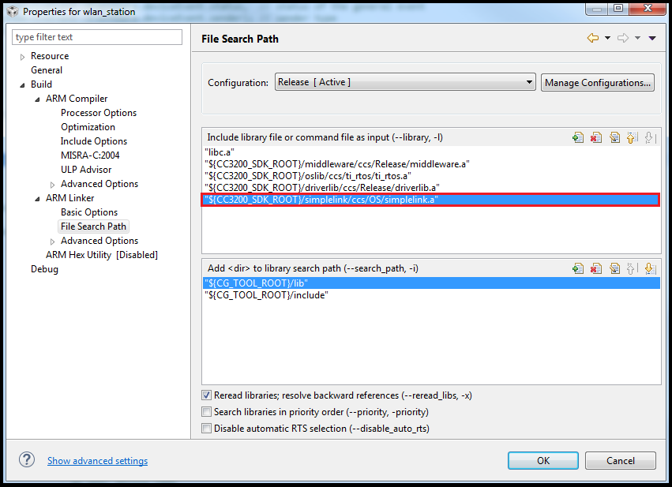

On IAR:

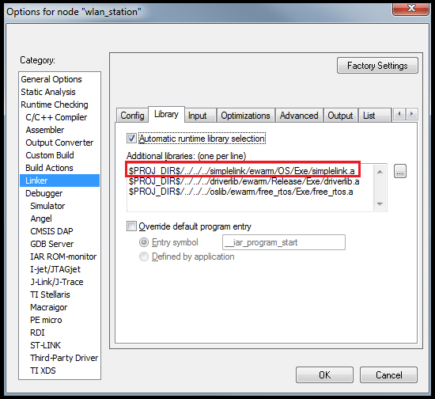

On GCC:

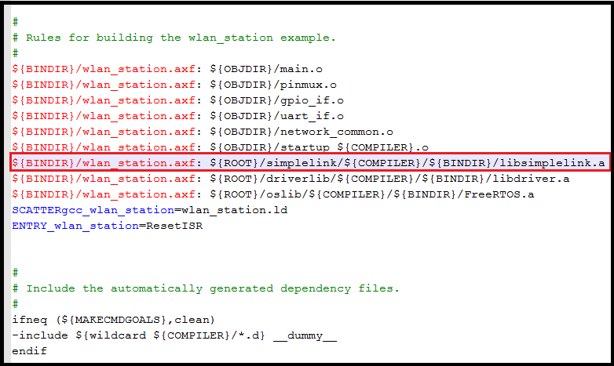

## Versioning

This product’s version follows a version format, **M.mm.pp.bb**, where **M** is a single digit Major number, **mm** is 2 digit minor number, **pp** is a 2 digit patch number, and **b** is an unrestricted set of digits used as an incremented build counter.

## Technical Support and Product Updates

- Visit the [E2E Forum](https://e2e.ti.com/support/wireless_connectivity/simplelink_wifi_cc31xx_cc32xx/f/)